# Проект SQL: Анализ оттока работников в R & D

Пирогова Анна, aipirogova

**Примечание к дэшборду:** по какой-то причине в скачанной версии html файла дэшборда подписи легенды могут перекрывать подписи осей, нужно просто уменьшить масштаб с помощью **‘ctrl -’**

## Задача

**Задача** - проанализировать отток работников в компании на основании имеющихся данных. Определить факторы, влияющие на то,**останется сотрудник, или уйдет**. На основании этих факторов предложить изменения, шаги, которые компания может предпринять, чтобы **уменьшить отток сотрудников**. Оценить результат с помощью метрик и создать **дешборд**.

## Анализ

### Данные и логика анализа

Подключаемся к базе и смотрим некоторые основные характеристики. Также подключаем необходимые библиотеки.

```r
library(DBI)
library(RMariaDB)
library(ggplot2)
library(tidymodels)
library(kableExtra)
library(OddsPlotty)
con <- dbConnect(RMariaDB::MariaDB(),
                 user='studentminor',
                 password='DataMinorHSE!2020',
                 dbname='employee',
                 host='34.88.193.134',
                 port = 3306)
```

- **profile** - общая информация о сотруднике
  - EmployeeNumber: id сотрудника
  - Age: возраст сотрудника
  - Education: уровень образования
  - EduFieldId: сфера образования (id, расшифровку см. в таблице education)
  - Gender: пол
  - MaritalStatus: семейный статус
  - NumCompaniesWorked: в скольких компаниях работал сотрудник
  - TotalWorkingYears: общий стаж работы (в течение жизни)
  - WorkLifeBalance: самооценка баланса работы и жизни (Bad-Good-Better-Best)
  - DistanceFromHome: расстояние от дома до работы в милях
- **portfolio** - информация о работе сотрудника
  - EmployeeNumber: id сотрудника
  - Attrition: остался сотрудник или нет (1- ушел, 0 - остался)
  - BusinessTravel: частота командировок
  - Department: в каком отделе работает сотрудник
  - EnvironmentSatisfaction: удовлетворенность окружением (Low-Medium-High-Very High)
  - JobInvolvement: вовлеченность в работу (Low-Medium-High-Very High)
  - JobRole: должность
  - JobSatisfaction: удовлетворенность рабочими задачами (Low-Medium-High-Very High)
  - MonthlyIncome: размер зарплаты
  - OverTime: есть ли переработка
  - PercentSalaryHike: на какой процент повышается зарплата
  - PerformanceRating: оценка результативности (Low-Good-Excellent-Outstanding)
  - RelationshipSatisfaction: удовлетворенность отношениями на работе (Low-Medium-High-Very High)
  - TrainingTimesLastYear: участие в программах повышение квалификации (число программ за последний год)
  - YearsAtCompany: стаж работы в компании
  - YearsInCurrentRole: стаж работы в текущей должности
  - YearsSinceLastPromotion: сколько лет прошло с последнего повышения
  - YearsWithCurrManager: сколько лет работает с текущим руководителем
- **education** – служебная таблица с расшифровкой сфер обучения
  - EduFieldId: id сферы образования
  - EducationField: сфера образования

Посмотрим на доступные таблицы и на данные таблицы Profile

```r
dbListTables(con)
```

```
## [1] "education" "portfolio" "profile"
```

```r
dbGetQuery(con, "select * from profile LIMIT 5")%>% kable(caption = "**Таблица Profile**") %>% kable_classic(full_width = F, html_font = "Cambria")
```

**Таблица Profile**

| EmployeeNumber | Age | Education | EduFieldId | Gender | MaritalStatus | NumCompaniesWorked | TotalWorkingYears | WorkLifeBalance | DistanceFromHome |
| --- | --- | --- | --- | --- | --- | --- | --- | --- | --- |
| 1 | 41 | College | edu2 | Female | Single | 8 | 8 | Bad | 1 |
| 2 | 49 | Below College | edu2 | Male | Married | 1 | 10 | Better | 8 |
| 4 | 37 | College | edu5 | Male | Single | 6 | 7 | Better | 2 |
| 5 | 33 | Master | edu2 | Female | Married | 1 | 8 | Better | 3 |
| 7 | 27 | Below College | edu4 | Male | Married | 9 | 6 | Better | 2 |

Посмотрим, сколько всего сотрудников в базе.

```r
d=dbGetQuery(con, "SELECT count(distinct EmployeeNumber) FROM profile")
d$'count(distinct EmployeeNumber)'[1]
```

```
## integer64
## [1] 1058
```

1058 сотрудников

```r
dep_leak=dbGetQuery(con, "with atr as(SELECT distinct Attrition,Department, count(EmployeeNumber) over(partition by Attrition, Department) as employees_numeber FROM profile join portfolio using(EmployeeNumber))
                    select Attrition,department, employees_numeber/sum(employees_numeber) over(partition by Attrition) as fraction_from_total_left from atr
           where attrition=0 order by fraction_from_total_left desc")
dep_leak %>% kable(caption = "**Распределение ушедших работников по департаментам**") %>% kable_classic(full_width = F, html_font = "Cambria")
```

| Attrition | department | fraction_from_total_left |
| --- | --- | --- |
| 0 | Research & Development | 0.6758 |
| 0 | Sales | 0.2878 |
| 0 | Human Resources | 0.0364 |

Предположу, что этот департамент является стратегически важным для компании в долгосрочной перспективе,поскольку R&D:

- R&D является источником конкуретных преимуществ
- Помогает разрабатывать инновационные продукты и новые технологии для поддержания инновационной бизнес-модели
- Также он помогает в улучшении оперативности и увеличивает продуктивность

Поэтому давайте рассмотрим его детальнее. Анализируем дальше. **Работники какого возраста ушли?**

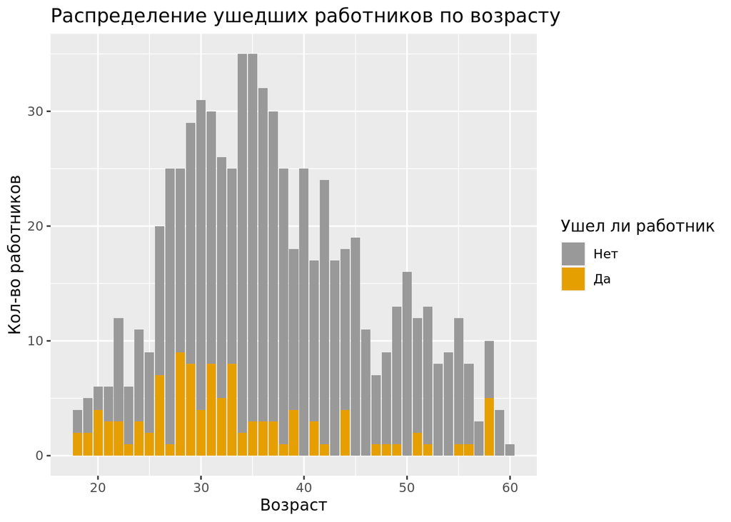

```r
leak_by_age=dbGetQuery(con, "select Age, Attrition from profile join portfolio on profile.EmployeeNumber=portfolio.EmployeeNumber where Department='Research & Development'")
leak_by_age$Attrition=as.factor(leak_by_age$Attrition)
new_label=c("Нет","Да")
levels(leak_by_age$Attrition)=new_label

cbPalette <- c("#999999", "#E69F00", "#56B4E9", "#009E73", "#F0E442", "#0072B2", "#D55E00", "#CC79A7")
ggplot(leak_by_age) + geom_bar(aes(x=Age,fill=Attrition))+scale_fill_manual(name="Ушел ли работник",values=cbPalette)+xlab('Возраст')+ylab('Кол-во работников')+ggtitle('Распределение ушедших работников по возрасту')
```

**Работники какого пола ушли?**

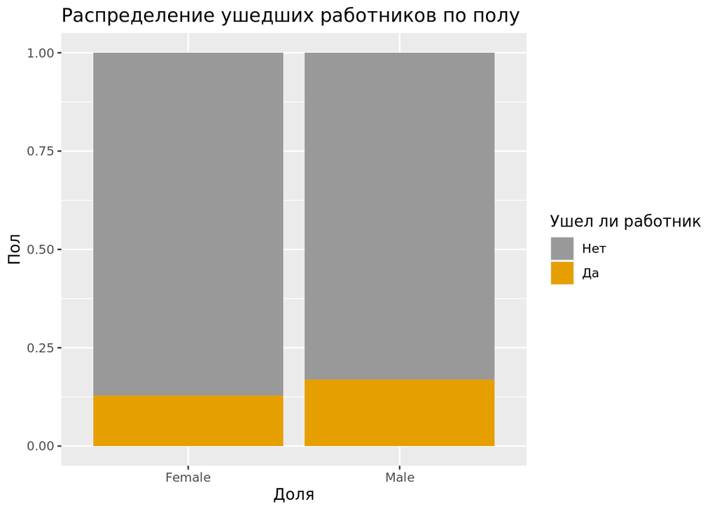

```r
leak_by_gender=dbGetQuery(con, "select Gender, Attrition from profile join portfolio on profile.EmployeeNumber=portfolio.EmployeeNumber where Department='Research & Development'")
leak_by_gender$Attrition=as.factor(leak_by_gender$Attrition)
new_label=c("Нет","Да")
levels(leak_by_gender$Attrition)=new_label

ggplot(leak_by_gender) + geom_bar(aes(x=Gender,fill=Attrition),position="fill")+scale_fill_manual(name="Ушел ли работник",values=cbPalette)+xlab('Доля')+ylab('Пол')+ggtitle('Распределение ушедших работников по полу')
```

В относительных значениях разницы практически нет. Продолжаем анализ.

Посмотрим, с **каких позиций уходят сотрудники в нашем департаменте.**

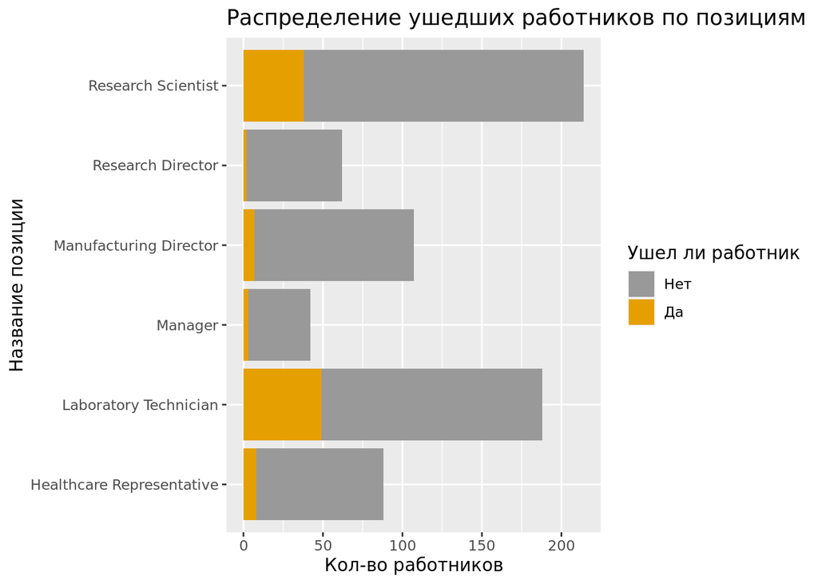

```r
x=dbGetQuery(con, "select JobRole, Attrition from profile join portfolio on profile.EmployeeNumber=portfolio.EmployeeNumber where Department='Research & Development'")
x$Attrition=as.factor(x$Attrition)
new_label=c("Нет","Да")
levels(x$Attrition)=new_label

ggplot(x) + geom_bar(aes(y=JobRole,fill=Attrition))+scale_fill_manual(name="Ушел ли работник",values=cbPalette)+xlab('Кол-во работников')+ylab('Название позиции')+ggtitle('Распределение ушедших работников по позициям')
```

Исходя из гистограммы, чаще уходят с позиций Laboratory Technician и Research Scientist, чем с других. **Может быть это как-то связано с заработной платой?** Проверим на следующем графике.

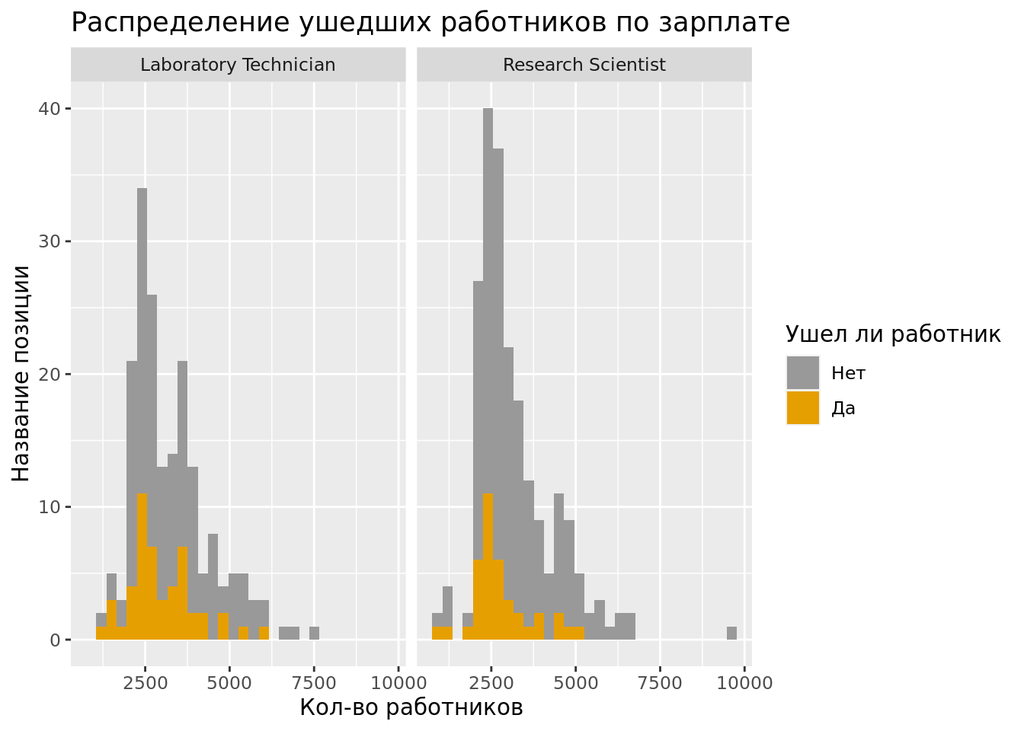

```r
y=dbGetQuery(con, "select JobRole, Attrition,MonthlyIncome from profile join portfolio on profile.EmployeeNumber=portfolio.EmployeeNumber where (Department='Research & Development' AND (JobRole='Laboratory Technician' OR JobRole='Research Scientist')) ")
y$Attrition=as.factor(y$Attrition)
new_label=c("Нет","Да")
levels(y$Attrition)=new_label

ggplot(y) + geom_histogram(aes(x=as.numeric(MonthlyIncome),fill=Attrition))+scale_fill_manual(name="Ушел ли работник",values=cbPalette)+xlab('Кол-во работников')+ylab('Название позиции')+ggtitle('Распределение ушедших работников по зарплате')+facet_grid(~JobRole)
```

Пока исходя лишь из графика сложно сделать какие-то выводы:распределение сильно смещено к левому краю, нельзя однозначно сказать, что ушли именно те, кому платили меньше. Поскольку на первый взгляд выявить факторы, влияющие на уход не удалось, перейдем к загрузке данных и построении модели.

### Модель

Загружаем данные по департаменту Research & Development

```r
data_group=dbGetQuery(con, "SELECT * FROM profile join portfolio on profile.EmployeeNumber=portfolio.EmployeeNumber
           join education on education.EduFieldId=profile.EduFieldId where Department='Research & Development'")
```

Преобразовываем данные, проходим циклом для конвертации character в numeric и factor, убираем id работника, id сферы образования, записываем id работника в rownames,уберем performance rating, поскольку там не хватает значений

```r
library(dplyr)
for (var in names(data_group)[c(3:6,9,13:18,20,22:23,25,29:30)]){
  data_group[[var]] = as.factor(data_group[[var]])
}

row.names(data_group)=data_group$EmployeeNumber
data_group=dplyr::select(data_group,-EmployeeNumber)
data_group=dplyr::select(data_group,-EduFieldId)
data_group=dplyr::select(data_group,-Department)
data_group$Attrition=as.factor(data_group$Attrition)
data_group=dplyr::select(data_group,-EmployeeNumber..11,-PerformanceRating,-EduFieldId..30)

for (var in names(data_group)[c(1,5:6,8,15,17,20:23)]){
  data_group[[var]] = as.numeric(data_group[[var]])
}
```

Построим **логистическую регрессию** для предсказания, уйдет работник или не уйдет. Используем ее по причине того, что модель дерева работает намного хуже на этих данных, показывая низкий roc_auc, а random forest - слишком сильно может подогнаться под наши данные, которых не очень много.

У нас **unbalanced dataset**, то есть одних классов намного больше, чем других (очень мало тех, кто ушли, и много тех, кто не ушли), поэтому если мы оставим данные как есть, модель будет плохо предсказывать minority class. И следовательно, мы не сможем адекватно оценить предпологаемые изменения. Поэтому мы делаем ресэмплинг, искусственно создавая допольнительные наблюдения для minority class с помощью **step_smote**. В этом случае баланс классов будет воссстановлен, и модель будет предсказывать тех, кто ушел, намного лучше.

Задаем **модель и ‘рецепт’**, в котором убираем предикторы с высокой корреляцией, а также создаем dummy variables.

```r
set.seed(1)
df_split <- initial_split(data_group,
prop = 0.8,
strata = Attrition)

df_train <- df_split %>%
training()

df_test <- df_split %>%
testing()

df_recipe <-
  recipe(Attrition ~ ., data = data_group) %>% step_corr(all_numeric(), threshold = 0.85) %>%  step_dummy(all_nominal(),-all_outcomes()) %>%  themis::step_smote(Attrition)

logistic_model <- logistic_reg() %>%
# Set the engine
set_engine("glm") %>%
# Set the mode
set_mode("classification")
```

Создадим **воркфлоу** и запустим тренировку на наших данных. Выведем метрики. А также выгрузим модель для дальнейшего использования в визуализации

```r
# Create a workflow
df_wkfl <- workflow() %>%
  # Include the model object
  add_model(logistic_model) %>%
  # Include the recipe object
  add_recipe(df_recipe)

# Train the workflow
df_wkfl_fit <- df_wkfl %>%
  last_fit(split = df_split)


fitted_wf <- pluck(df_wkfl_fit$.workflow, 1)
# Obtain class predictions
class_preds <- predict(fitted_wf, new_data = df_test,
                   type = 'class')
# Obtain estimated probabilities
prob_preds <- predict(fitted_wf, new_data = df_test,
                  type='prob')


# Combine test set results
empl_results <- df_test %>%
  select(Attrition) %>%
  bind_cols(class_preds,prob_preds)


# Calculate the accuracy
accuracy(empl_results, truth=Attrition,
    estimate = .pred_class)%>% kable(caption = "**Метрика accuracy для модели на тестовом датасете**") %>% kable_classic(full_width = F, html_font = "Cambria")
```

**Метрика accuracy для модели на тестовом датасете**

| .metric | .estimator | .estimate |
| --- | --- | --- |
| accuracy | binary | 0.8085106 |

```r
# Calculate the sensitivity
sens(empl_results, truth=Attrition,
    estimate = .pred_class)%>% kable(caption = "**Метрика sensitivity для модели на тестовом датасете**") %>% kable_classic(full_width = F, html_font = "Cambria")
```

**Метрика sensitivity для модели на тестовом датасете**

| .metric | .estimator | .estimate |
| --- | --- | --- |
| sens | binary | 0.8235294 |

```r
# Calculate the specificity
spec(empl_results, truth=Attrition,
    estimate = .pred_class)%>% kable(caption = "**Метрика specificity для модели на тестовом датасете**") %>% kable_classic(full_width = F, html_font = "Cambria")
```

**Метрика specificity для модели на тестовом датасете**

| .metric | .estimator | .estimate |
| --- | --- | --- |
| spec | binary | 0.7272727 |

```r
model=extract_fit_engine(df_wkfl_fit)
```

Метрики показывают хорошие результаты, учитывая, что у нас был unbalanced dataset и мы генерировали дополнительные синтетические наблюдения для minority class.

Визуализируем нашу модель с помощью Odds plot, он показывает, насколько сильно различные факторы влияют на вероятнось ухода. Поскольку не весь график виден четко, выведем дополнительно значения odds ratio для всех переменных.

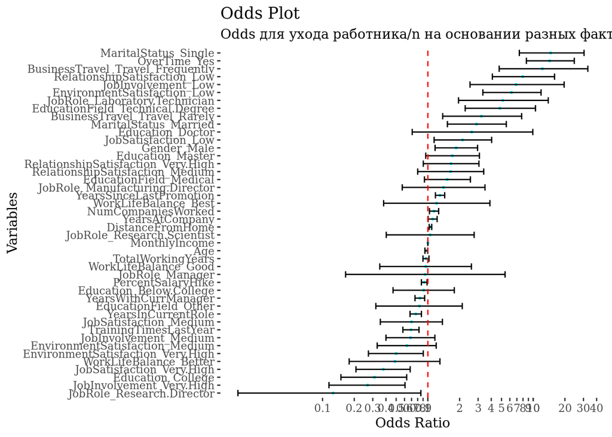

```r
plotty <- OddsPlotty::odds_plot(model,
                      title = "Odds Plot",
                      subtitle = "Odds для ухода работника/n на основании разных факторов",
                      point_col = "#00f2ff",
                      error_bar_colour = "black",
                      point_size = .5,
                      error_bar_width = .8,
                      h_line_color = "red")
plotty$odds_plot + ggthemes::theme_tufte()
```

```r
plotty$odds_data %>% kable(caption = "**Odds ratio для разных факторов**") %>% kable_classic(full_width = F, html_font = "Cambria") %>%  kable_paper() %>%  scroll_box(width = "100%", height = "300px")
```

**Odds ratio для разных факторов**

| OR | lower | upper | vars |
| --- | --- | --- | --- |
| 0.9669849 | 0.9373437 | 0.9969246 | Age |
| 1.1436713 | 1.0350924 | 1.2656510 | NumCompaniesWorked |
| 0.9597698 | 0.8985681 | 1.0240959 | TotalWorkingYears |
| 1.0583181 | 1.0299764 | 1.0881978 | DistanceFromHome |
| 0.9999887 | 0.9998269 | 1.0001491 | MonthlyIncome |
| 0.9238415 | 0.8679242 | 0.9824745 | PercentSalaryHike |
| 0.6923288 | 0.5789229 | 0.8237396 | TrainingTimesLastYear |
| 1.1092781 | 1.0046739 | 1.2239900 | YearsAtCompany |
| 0.7683735 | 0.6774399 | 0.8685719 | YearsInCurrentRole |
| 1.3021283 | 1.1790970 | 1.4452095 | YearsSinceLastPromotion |
| 0.8396171 | 0.7545886 | 0.9318976 | YearsWithCurrManager |
| 0.9124302 | 0.4670126 | 1.7825090 | Education_Below.College |
| 0.3112326 | 0.1494462 | 0.6293103 | Education_College |
| 2.6056422 | 0.7099065 | 9.9159615 | Education_Doctor |
| 1.7084072 | 0.9543215 | 3.0863496 | Education_Master |
| 1.8561295 | 1.1710417 | 2.9642640 | Gender_Male |
| 2.8932323 | 1.5327897 | 5.5558911 | MaritalStatus_Married |
| 14.6498576 | 7.3875277 | 30.4065933 | MaritalStatus_Single |
| 1.2099961 | 0.3800905 | 3.8830412 | WorkLifeBalance_Best |
| 0.4864628 | 0.1790077 | 1.3012412 | WorkLifeBalance_Better |
| 0.9559823 | 0.3493203 | 2.5907115 | WorkLifeBalance_Good |
| 12.2291936 | 4.7525232 | 33.0276786 | BusinessTravel_Travel_Frequently |
| 3.2222721 | 1.3823680 | 7.7718789 | BusinessTravel_Travel_Rarely |
| 6.2143939 | 3.3260373 | 11.8708394 | EnvironmentSatisfaction_Low |
| 0.6323923 | 0.3301158 | 1.2000545 | EnvironmentSatisfaction_Medium |
| 0.4997505 | 0.2724878 | 0.9047003 | EnvironmentSatisfaction_Very.High |
| 6.8724387 | 2.5125040 | 19.6714209 | JobInvolvement_Low |
| 0.6851118 | 0.4000926 | 1.1658831 | JobInvolvement_Medium |
| 0.2676061 | 0.1150745 | 0.6066526 | JobInvolvement_Very.High |
| 5.1478158 | 1.9548540 | 13.8954762 | JobRole_Laboratory.Technician |
| 0.9412970 | 0.1655020 | 5.4064490 | JobRole_Manager |
| 1.4070962 | 0.5708801 | 3.4847561 | JobRole_Manufacturing.Director |
| 0.1259377 | 0.0157220 | 0.8574421 | JobRole_Research.Director |
| 1.0492606 | 0.4025002 | 2.7494462 | JobRole_Research.Scientist |
| 2.1361687 | 1.1463904 | 4.0320598 | JobSatisfaction_Low |
| 0.6995950 | 0.3535031 | 1.3747089 | JobSatisfaction_Medium |
| 0.3778291 | 0.2076013 | 0.6794307 | JobSatisfaction_Very.High |
| 14.3291988 | 8.6184425 | 24.5511961 | OverTime_Yes |
| 7.9532756 | 4.0945021 | 15.9500160 | RelationshipSatisfaction_Low |
| 1.6443772 | 0.8001257 | 3.3892698 | RelationshipSatisfaction_Medium |
| 1.6568349 | 0.9047334 | 3.0545098 | RelationshipSatisfaction_Very.High |
| 1.5287980 | 0.9276385 | 2.5334315 | EducationField_Medical |
| 0.8331686 | 0.3205295 | 2.1207602 | EducationField_Other |
| 4.8249269 | 2.2619242 | 10.5114743 | EducationField_Technical.Degree |

Из этого графика можно сделать выводы для улучшения ситуации в компании.

### Симуляция

Предложим изменения направленные на : повышение тех характеристик, которые уменьшают вероятность ухода, а также сокращение тех характеристик, которые увеличивают шанс ухода. Изменения:

- Представим, что компания провела работу по оптимизации нагрузки сотрудников, и теперь никто из сотрудников не работает сверх нормы (Достаточно амбициозная задача, но этот случай нам легко будет смоделировать, заодно мы сможем увидеть “максимальный эффект”, который возможно достигнуть)
- Представим, что удовлетворенность от работы повысилась на одну единицу (То есть, у кого она была Low, стала Medium, Medium - High, High- Very High, Very High-Very High) Внесем изменения в датасет, и предскажем уход сотрудников уже на новых данных.

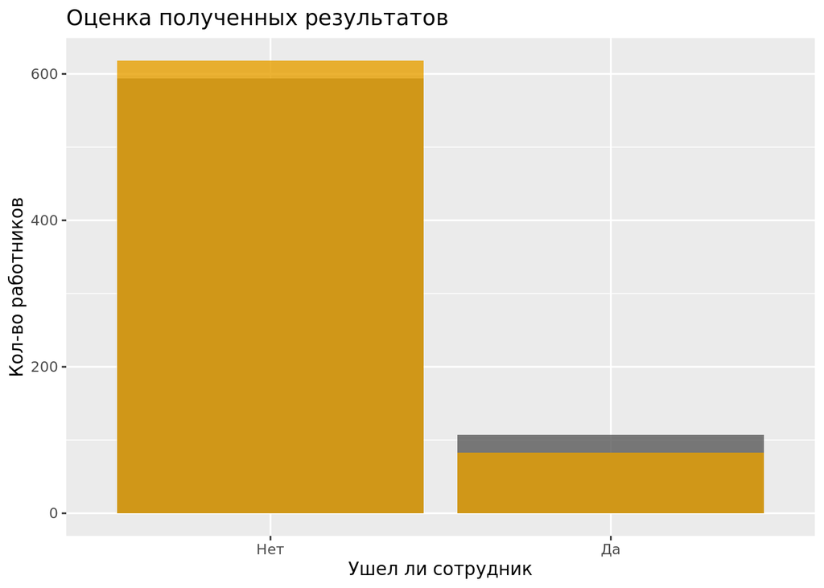

```r
data_new=data_group
data_new = data_new %>% mutate(Overtime=as.factor("No"))
levels(data_new$Overtime) <- c(levels(data_new$Overtime),"Yes")

data_new$OverTime=data_new$Overtime
data_new=dplyr::select(data_new,-Overtime)



data_new = data_new %>% mutate(JobSatisfaction_new = case_when(
                                                     JobSatisfaction == "Medium" ~ "High",
                    JobSatisfaction == "High" ~ "Very High",
                      JobSatisfaction=="Very High"  ~ "Very High",
                          JobSatisfaction=="Low"  ~ "Medium"))
levels(data_new$JobSatisfaction_new) <- c(levels(data_new$JobSatisfaction_new),"Low")
data_new$JobSatisfaction_new <- factor(data_new$JobSatisfaction_new, levels= c("High","Low","Medium","Very High"))
data_new$JobSatisfaction=data_new$JobSatisfaction_new
data_new=dplyr::select(data_new,-JobSatisfaction_new)



fitted_wf <- pluck(df_wkfl_fit$.workflow, 1)
predTest=predict(fitted_wf, new_data = data_new)

my_x_labels <- setNames(c("Нет", "Да"),
                        c("0", "1"))
ggplot(data_group) + geom_bar(aes(x = Attrition), alpha = 0.8)+
   geom_bar(data = predTest,aes(x = .pred_class), alpha = 0.8,fill="#E69F00")+ggtitle('Оценка полученных результатов') + xlab('Ушел ли сотрудник')+ylab('Кол-во работников')+ scale_x_discrete(labels = my_x_labels)
```

```r
impr_results=predTest %>% group_by(.pred_class) %>% summarize(cnt=n())

old_results=data_group %>% group_by(Attrition) %>% summarize(cnt=n())
```

Посчитаем, на сколько процентов нам удалось уменьшить отток работников

```r
round(-100*(impr_results$cnt[[2]]-old_results$cnt[[2]])/old_results$cnt[[2]],2)
```

```
## [1] 22.43
```

```r
dbDisconnect(con)
```

### Дэшборд

Вынесем в дешборд :

- новый график: scatter plot, отобращающий отток сотрудников по возрасту и зарплате с возможностью фильтрации по позициям, удовлетворенностью работы
- метрики: процент оттока сотрудников до и после улучшений, на сколько процентов сократилось
- новый график: bar chart, отображающий факторы, влияющие на уход или неуход сотрудника (визуализция odds ratio из odd plot, на основе построенной модели)

Дэшборд предназначен для hr, которые смогут посмотреть отток сотрудников по разным позициям и другим фильтрам для принятия решения об изменение/неизменении политики компании в отношении существующих проблем.

## Общие выводы

Отвечая на вопрос, какие факторы влияют на уход сотрудников из компании можно сказать, что увеличивают риск ухода :

- переработки
- частые командировки
- низкая удовлетворенность рабочими отношениями и средой
- низкая вовлеченнность

В целом это представляется логичным, поскольку вышеперечисленное уменьшает привлекательность работы в глазах сотрудника. Также мы выяснили, что сотрудники с семейным положением single уходят чаще, что тоже логично, поскольку такие сотрудники более мобильны и не так сильно привязаны к конкретному месту работы. (Но поскольку на этот фактор впрямую повлиять невозможно, в анализ его не включаем.) Касательно факторов, которые снижают риск ухода сотрудников, можно выделить :

- высокую вовлеченность в работу
- высокую удовлетворенность рабочей обстановкой и самой работой

Тем не менее, модель, хотя и показывает хорошие результаты, она не может со 100% вероятностью предсказать тех, кто уйдет, поскольку всегда остаются какие-то паттерны и зависимости вне поле зрения модели (Это связано и с относительно **небольшим числом наблюдений**, а также **ommitted variable bias**, то есть - когда отсутствуют важные переменные.) В нашем датасете мы убрали очень важную переменную, в которой была оценка performance сотрудников, поскольку в ней были пропущены значения. Однако это очень важная переменная с той точки зрения, что она помогла бы улучшить модель, а также оценить, насколько ценными для компании были сотрудники, которые ушли. И мы могли бы оценить улучшения тоже в терминах low и high performers.

В любом случае, те факторы, которые были выявлены моделью, **имеют влияние** на отток сотрудников из компании, поэтому целесообразно вносить изменения в политику компании, не допускать переработок, сокращать кол-во командировок на одного сотрудника, решать проблемы, которые вызывают низкую удовлетворенность рабочей обстановкой и рабочими отношениями. Безусловно, что эти изменения будут стоить компании каких-то материальных ресурсов, однако не стоит забывать, что каждый уход сотрудника из компании это тоже потеря ресурсов: времени и денег, потраченного на обучение и поиск сотрудника, а также времени и денег, потраченные на поиск нового. Поэтому, работать над уменьшением оттока сотрудников полезно.

В заключение отметим, что уровень в 10% (оттока сотрудников) является средним, но могут быть различия для конкретной индустрии, поэтому компании стоит брать показатель для своей индустрии за целевой. Изменения, которые были предложены, снизили отток с **15.26% до 11.84% на 22.43%**, они могут быть дополнены и должны быть дополнены работой менеджмента по устранению проблем в удовлетворенности рабочими отношениями и средой, а также возможно использовать какие- то материальные надбавки для молодых сотрудников до 25 лет, чтобы уменьшить риск их ухода.